# A3: SPL Library Checkouts

### Introduction

Quarantine as a result of the Pandemic has definitely impact the way in which individuals interact with public resources, especially the public library system. My intention was to examine how this phenomenon affect different groups of people based on different genres and authors. Because of this, I focused my analysis on books as material type, as it is a physical type that is traditional and I am the most familiar with. I chose to examine trends in a popular children author, a manga/graphic novel artists, and in general some of the highest checkouts for a publishing firm more focused more catered to adults. As a result, I hope to be able to draw conclusions and learn about the impact a more virtual had on different areas of reading print books from the library.

### Summary Information

Of the Data set spl.books.df that I filtered from the original dataset, there are 305755 rows, all of which are print books. March is the month with the lowest average checkouts, 20.50054, and December is the month with the highest, 22.36761. 2018 had the most average checkouts, with 22.08533, and 2022 had the least, with 20.23024. 2017 was the year with the most checkouts of the book “Lego Star Wars : attack of the clones”

### Cleary Over Time Chart

This chart of how many times select Beverly Cleary books were checked out over time, and was included because how much impact they had on my childhood, and I was curious to compare how the last few years affected popular children book being checked out from the public library. Of the three books, although I remember them being equally popular in my youth, there was a clear difference in current popularity. That being said, generally they followed the trend of decreased checkouts in 2020, and a quick resurrgence in 2021, but then lower again in 2022.

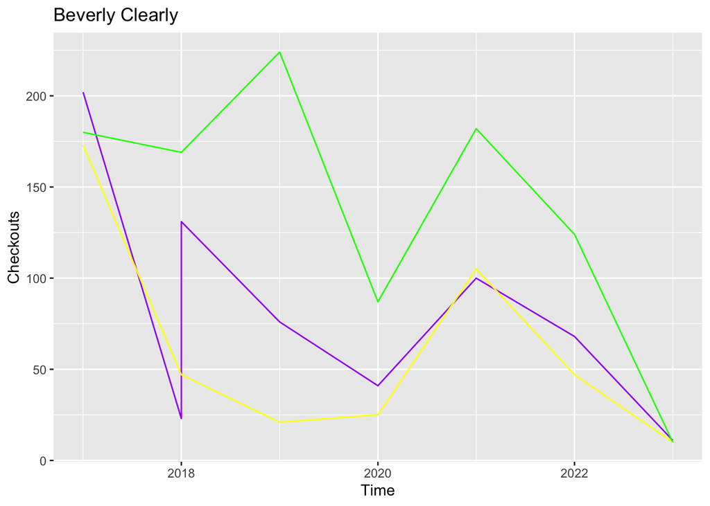

### Graphic Novels Over Time Chart

This chart was included to attempt to track the activities of a different age group: adolescents and young adults. To do so, one popular area is young adult graphic novels and manga, and two very popular publishing firms for that are First Second here in the US, and Viz Media in Japan. The primary pattern that emerged was the fact that First Second had more cummulative yearly checkouts, but this is also because they had far more books. Over time, there is a large drop leading into 2020, with First Second having a peak in 2019 and Viz Media decreasing overtime.

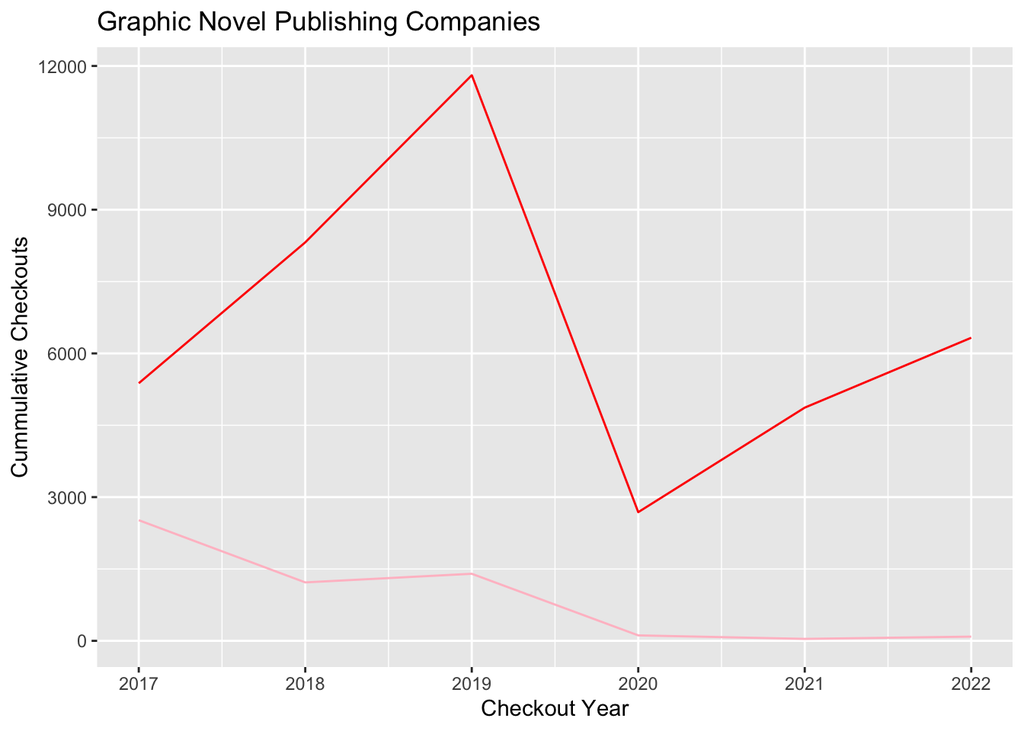

### Riverhead Books Highest Checkouts

This chart was included to examine the activites of the highest performing overall checkouts for a publishing firm, which caters mostly to an adult audience, to see how often they were being checked over the entire period. Unsurprisingly, I am not familar with many of these titles, which is to be expected. However, these numbers are not as large as I had hypothesized they would be.

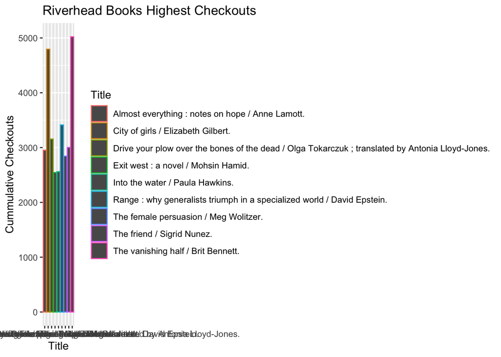